# Trabajo N°6

Arqueología Cuantitativa

Esteban Arroyo y Patricio De Souza

28-11-2022

# Trabajo N°6

## Resuelva los siguientes dos problemas planteados, considerando la materia pasada en clases en relación a muestreo probabilístico. La información que necesita se encuentra en el archivo BD_trabajo_6_TAC_2022.xlsx. Detalle y justifique los criterios aplicados y los procedimientos matemáticos empleado.

## **PREGUNTA 1**

### Se obtuvieron muestras por azar simple del 20% de las puntas de proyectil recuperadas de dos sitios arqueológicos (A1 y A2), midiéndose individualmente el largo de los todos los ejemplares seleccionados (Tabla N°1). Para cada sitio, se desea establecer una estimación de la media poblacional, considerando un 95% de confianza. Calcule el error en torno a la media de la muestra y el intervalo de confianza correspondiente para cada caso, indicando cuál sitio ofrece una mejor precisión en la estimación. Explique por qué las estimaciones ofrecen para un caso una mejor precisión que para el otro, pese a que de ambos sitios se extrajeron fracciones de muestreo idénticas.

### Cargamos nuestra librería readxl y cargamos el fichero de excel

```r
library("readxl")
```

### Cargamos las bases de datos según “Tabla 1”, “Tabla 2” y “Tabla 3”

```r
base1 <- read_excel("BD_trabajo6_TAC2022.xlsx", sheet="Tabla 1")
base2 <- read_excel("BD_trabajo6_TAC2022.xlsx", sheet="Tabla 2")
base3 <- read_excel("BD_trabajo6_TAC2022.xlsx", sheet="Tabla 3")
```

### Cargamos las librerías que necesitamos

```r
library(dplyr)
library(janitor)
library(flextable)
library(ggplot2)
library(samplingbook)
```

### Para Población Total

```r
n <- nrow(base1)           #Tamaño de la Base
fraccion <- 20             #Fracción de la Población al 20%
N <- (n*100)/fraccion      #Tamaño de la Población
est <- Smean(y = base1$`Largo (cms)`, N = N)
est
```

```
##
## Smean object: Sample mean estimate
## With finite population correction: N=430
##
## Mean estimate: 8.6229
## Standard error: 0.2132
## 95% confidence interval: [8.205,9.0408]
```

```r
cat("Hay un probabilidad del 95% que el promedio del Largo (cms) de puntas de proyectil de la población esté entre: ", round(est$ci[1],2), "cms y ", round(est$ci[2],2), "cms, respectivamente, para la Población Total")
```

```
## Hay un probabilidad del 95% que el promedio del Largo (cms) de puntas de proyectil de la población esté entre:  8.2 cms y  9.04 cms, respectivamente, para la Población Total
```

### Para Sitio A1

```r
a1 <- base1[base1$Sitio == "A1",]           #Base filtrada por sitio A1
N1 <- (nrow(a1)*N)/nrow(base1)              #Tamaño de población según sitio A1
est1 <- Smean(y = a1$`Largo (cms)`, N = N1)
est1
```

```
##
## Smean object: Sample mean estimate
## With finite population correction: N=180
##
## Mean estimate: 8.4461
## Standard error: 0.3423
## 95% confidence interval: [7.7752,9.117]
```

```r
cat("Hay un probabilidad del 95% que el promedio del Largo (cms) de puntas de proyectil de la población esté entre: ", round(est1$ci[1],2), "cms y ", round(est1$ci[2],2), "cms, respectivamente, para el Sitio A1")
```

```
## Hay un probabilidad del 95% que el promedio del Largo (cms) de puntas de proyectil de la población esté entre:  7.78 cms y  9.12 cms, respectivamente, para el Sitio A1
```

### Para Sitio A2

```r
a2 <- base1[base1$Sitio == "A2",]             #Base filtrada por sitio A2
N2 <- (nrow(a2)*N)/nrow(base1)                #Tamaño de población según sitio A2
est2 <- Smean(y = a2$`Largo (cms)`, N = N2)
est2
```

```
##
## Smean object: Sample mean estimate
## With finite population correction: N=250
##
## Mean estimate: 8.7502
## Standard error: 0.2734
## 95% confidence interval: [8.2143,9.2861]
```

```r
cat("Hay un probabilidad del 95% que el promedio del Largo (cms) de puntas de proyectil de la población esté entre: ", round(est2$ci[1],2), "cms y ", round(est2$ci[2],2), "cms, respectivamente, para el Sitio A2")
```

```
## Hay un probabilidad del 95% que el promedio del Largo (cms) de puntas de proyectil de la población esté entre:  8.21 cms y  9.29 cms, respectivamente, para el Sitio A2
```

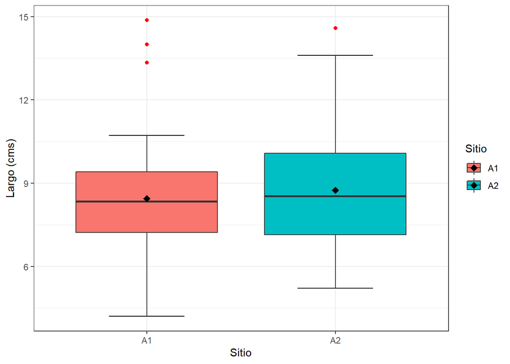

```r
ggplot(data = base1, aes(x=Sitio, y=`Largo (cms)`, fill=Sitio)) + stat_boxplot(geom="errorbar", width = 0.4) + geom_boxplot(outlier.colour = "red") + stat_summary(fun=mean,geom="point",shape=18,size=3,color="black") + theme_bw()
```

```r
data.frame("Etiqueta"=c("Error", "Li", "Ls"), "Sitio A1" = c(est1$se, est1$ci[1], est1$ci[2]), "Sitio A2"=c(est2$se, est2$ci[1], est2$ci[2])) %>% flextable() %>% set_caption("Tabla resumen de error standar de la media  e Intervalos al 95%") %>% bg(bg="#0000FF", part = "header") %>% color(color = "white", part = "header")%>% theme_box()
```

Tabla resumen de error standar de la media e Intervalos al 95%

| Etiqueta | Sitio.A1 | Sitio.A2 |
| --- | --- | --- |
| Error | 0.3422887 | 0.2734479 |
| Li | 7.7752376 | 8.2142519 |
| Ls | 9.1169846 | 9.2861481 |

### Finalmente se puede observar que la mayor precisión en la estimación corresponde al Sitio A2, porque el error standar de la media es menor en relación con el sitio A1, y esto se debe al tamaño muestral, ya que es mayor en el sitio A2.

## **PREGUNTA 2**

### La tabla N°2 representa la mitad de la población de lascas extraídas de un sitio dado. Calcular el tamaño de muestra necesario para obtener una muestra representativa de la proporción de obsidianas, considerando un 5% de error y bajo un 95% de confianza.

```r
N3 <- nrow(base2)                                 #Tamaño de la base
fraccion2 <- 50/100                               #Fracción de la Población al 50%
Nt <- N3/fraccion2                                #Tamaño de la Población (es lo mismo que 591 * 2 = 1182)
p <- sum(with(base2, MP == "Obsidiana"))/N3       #Proporción de Obsidiana
sample.size.prop(e=0.05, P = p, level=0.95, N=Nt)
```

```
##
## sample.size.prop object: Sample size for proportion estimate
## With finite population correction: N=1182, precision e=0.05 and expected proportion P=0.1861
##
## Sample size needed: 195
```

### El tamaño de muestra representativa para estimar la proporción de obsidianas de la Población es de 195 lascas

## **PREGUNTA 3**

### También para la tabla N°2, calcule el tamaño de muestra necesario pero esta vez en función de la media de los largos morfológicos. Considere un error de 1.7 como máximo admisible y una confianza del 95%. Posteriormente realice un muestreo estratificado proporcional según materias primas y luego calcule el error estándar de la media de la muestra y el intervalo al 95% de confianza para cada estrato.

### Tamaño de Muestra

```r
s <- sd(base2$Largo_morfológico)
sample.size.mean(e=1.7, S=s, level = 0.95, N = Nt)   #Usamos la población Total (1182)
```

```
##
## sample.size.mean object: Sample size for mean estimate
## With finite population correction: N=1182, precision e=1.7 and standard deviation S=15.4925
##
## Sample size needed: 252
```

### El tamaño de muestra representativa para estimar la media de los largos morfológicos de la Población es de 252 lascas

### Muestreo Estratificado proporcional

```r
# Revisamos las frecuencias de las materias primas de nuestra base
data.frame(table(base2$MP)) %>% adorn_totals(c("row"))  %>% flextable() %>% set_header_labels("Var1" = "MP", "Freq" = "N") %>% bg(bg="#0000FF", part = "header") %>%   color(color = "white", part = "header") %>% bg(i = 5, bg="#0000FF", part = "body") %>% color(i = 5, color = "white", part = "body")
```

| MP | N |
| --- | --- |
| Basalto | 118 |
| Obsidiana | 110 |
| Silíceas | 175 |
| Toba | 188 |
| Total | 591 |

### Calculamos las porporciones de cada MP

```r
bas <- sum(with(base2, MP == "Basalto"))/N3
obs <- sum(with(base2, MP == "Obsidiana"))/N3
sil <- sum(with(base2, MP == "Silíceas"))/N3
tob <- sum(with(base2, MP == "Toba"))/N3
```

### Usaremos la función strata() del paquete sampling

```r
library(sampling)
```

```r
set.seed(5)
estra <- sampling:::strata(data=base2, stratanames = "MP", size = c(round(252*bas), round(252*obs), round(252*sil), round(252*tob)), method = "srswor")
```

### Revisamos el tamaño de los estratos ajustados proporcionalmente

```r
data.frame(table(estra$MP)) %>% adorn_totals(c("row")) %>% flextable() %>% set_header_labels("Var1" = "MP", "Freq" = "n") %>% bg(bg="#0000FF", part = "header") %>%   color(color = "white", part = "header") %>% bg(i = 5, bg="#0000FF", part = "body") %>% color(i = 5, color = "white", part = "body")
```

| MP | n |
| --- | --- |
| Basalto | 50 |
| Obsidiana | 47 |
| Silíceas | 75 |
| Toba | 80 |
| Total | 252 |

### Vemos todo en una tabla comparativa

```r
c1 <- data.frame(table(base2$MP))
c2 <- data.frame(table(estra$MP))
ctod <- merge(c1,c2, by = "Var1")
names(ctod) =  c("MP","N","n")

ctod %>% adorn_totals(c("row")) %>%
  flextable() %>% theme_vanilla() %>% bg(bg="#0000FF", part = "header") %>%
  color(color = "white", part = "header") %>% bg(i = 5, bg="#0000FF", part = "body") %>% color(i = 5, color = "white", part = "body")
```

| MP | N | n |
| --- | --- | --- |
| Basalto | 118 | 50 |
| Obsidiana | 110 | 47 |
| Silíceas | 175 | 75 |
| Toba | 188 | 80 |
| Total | 591 | 252 |

### Generamos finalmente la muestra con nuesta base

```r
muestra <- getdata(base2, estra)
```

### Intervalo de confianza para la media

### Para Población Total

```r
est3 <- Smean(y = muestra$Largo_morfológico, N = Nt)  #Usamos la porblación Total (1182)
est3
```

```
##
## Smean object: Sample mean estimate
## With finite population correction: N=1182
##
## Mean estimate: 37.5493
## Standard error: 0.9223
## 95% confidence interval: [35.7416,39.3569]
```

### Para Estrato Basalto

```r
base_bas <- muestra[muestra$MP == "Basalto",]                      #filtramos la base por Basalto
est4 <- Smean(y = base_bas$Largo_morfológico, N = round(Nt*bas))   #usamos la porporción de Basalto para la población total
est4
```

```
##
## Smean object: Sample mean estimate
## With finite population correction: N=236
##
## Mean estimate: 37.9344
## Standard error: 0.6505
## 95% confidence interval: [36.6595,39.2093]
```

### Para Estrato Obsidiana

```r
base_obs <- muestra[muestra$MP == "Obsidiana",]                    #filtramos la base por Obsidiana
est5 <- Smean(y = base_obs$Largo_morfológico, N = round(Nt*obs))   #usamos la porporción de Obsidiana para la población total
est5
```

```
##
## Smean object: Sample mean estimate
## With finite population correction: N=220
##
## Mean estimate: 23.4428
## Standard error: 0.8074
## 95% confidence interval: [21.8603,25.0253]
```

### Para Estrato Silíceas

```r
base_sil <- muestra[muestra$MP == "Silíceas",]                     #filtramos la base por Silíceas
est6 <- Smean(y = base_sil$Largo_morfológico, N = round(Nt*sil))   #usamos la porporción de Silíceas para la población total
est6
```

```
##
## Smean object: Sample mean estimate
## With finite population correction: N=350
##
## Mean estimate: 27.0164
## Standard error: 0.6148
## 95% confidence interval: [25.8115,28.2213]
```

### Para Estrato Toba

```r
base_tob <- muestra[muestra$MP == "Toba",]                         #filtramos la base por Toba
est7 <- Smean(y = base_tob$Largo_morfológico, N = round(Nt*tob))   #usamos la porporción de Toba para la población total
est7
```

```
##
## Smean object: Sample mean estimate
## With finite population correction: N=376
##
## Mean estimate: 55.4708
## Standard error: 1.5477
## 95% confidence interval: [52.4374,58.5041]
```

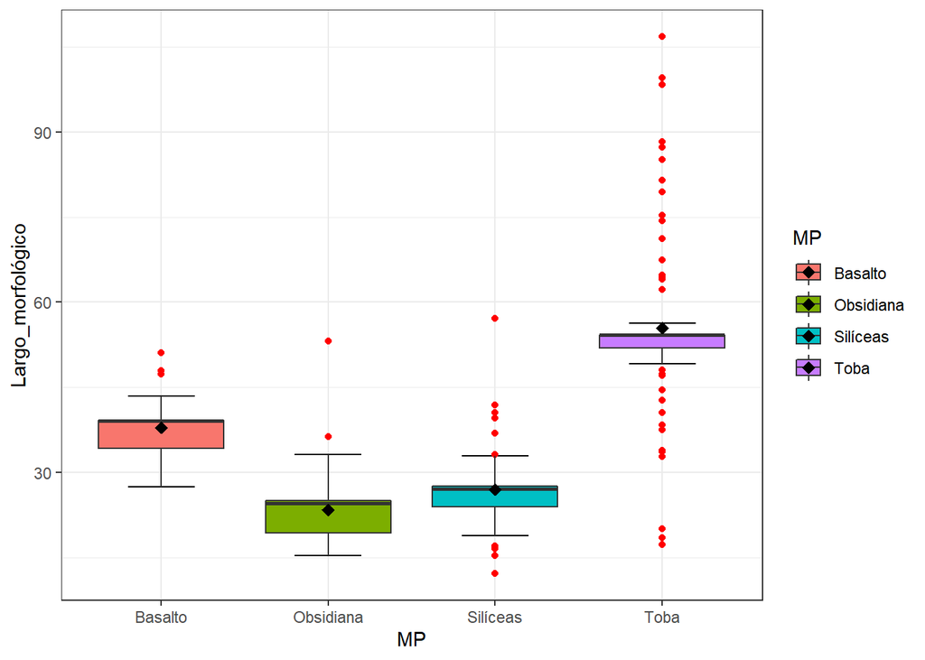

```r
ggplot(data = muestra, aes(x=MP, y=Largo_morfológico, fill=MP)) + stat_boxplot(geom="errorbar", width = 0.4) + geom_boxplot(outlier.colour = "red") + stat_summary(fun=mean,geom="point",shape=18,size=3,color="black") + theme_bw()
```

```r
data.frame("Etiqueta"=c("Error", "Li", "Ls"), "Basalto" = c(est4$se, est4$ci[1], est4$ci[2]), "Obsidiana"=c(est5$se, est5$ci[1], est5$ci[2]), "Silíceas" = c(est6$se, est6$ci[1], est6$ci[2]), "Toba" = c(est7$se, est7$ci[1], est7$ci[2])) %>% flextable() %>% set_caption("Tabla resumen de error standar de la media  e Intervalos al 95%") %>% bg(bg="#0000FF", part = "header") %>% color(color = "white", part = "header") %>% theme_box()
```

Tabla resumen de error standar de la media e Intervalos al 95%

| Etiqueta | Basalto | Obsidiana | Silíceas | Toba |
| --- | --- | --- | --- | --- |
| Error | 0.6504678 | 0.80742 | 0.6147772 | 1.54768 |
| Li | 36.6595066 | 21.86025 | 25.8114588 | 52.43735 |
| Ls | 39.2092934 | 25.02528 | 28.2213412 | 58.50415 |

## **PREGUNTA 4**

### Se quiere efectuar un estudio del tamaño máximo de los desechos de talla dentro de un pequeño taller arqueológico que mide 12 m2 de superficie y cuyo depósito es de 1,1 m de profundidad. Para lo anterior, se excavó un pozo de sondeo de 0,25 m2, del cual se extrajeron 155 desechos de talla. Con el fin de estimar la variabilidad del conjunto, se midió el tamaño de 50 de los desechos extraídos (Tabla N°3). ¿Cuántos pozos de sondeo de iguales dimensiones al efectuado deberían implementarse para extraer una muestra que sea representativa de los tamaños de los desechos de talla de todo el sitio? Considere un intervalo de confianza del 95% y errores de 0,1 y 0,05 cm en el tamaño máximo. Asuma una densidad homogénea de desechos de talla a lo largo del sitio.

### Definimos la desviación típica de Tamaño max, el tamaño total de cuadrículas y el total de desechos

```r
s_talla <- sd(base3$`Tamaño max. (cms)`)
N_cuadri <- 48  #El total de cuadrículas en 12 m2 de 0.25 m2 es: 12/0.25 o lo que es lo mismo: en 1 m2 hay 4 de 0.25 m2, por tanto 4*12 = 48
Total_Desechos <- N_cuadri*155  #Multiplicamos el total de cuadrículas por 155 asumiendo que la misma cantidad de desechos se encontraran en el total de cuadrículas.
```

### Usamos la función sample.size.mean del paquete samplingbook

### Empezamos calculando al muestra con error 0.1

```r
n2 <- sample.size.mean(e=0.1, S=s_talla, level = 0.95, N = Total_Desechos)  # Usamos error de 0,1
n2  # Esto nos da la muestra de desechos corregido para poblaciones finitas
```

```
##
## sample.size.mean object: Sample size for mean estimate
## With finite population correction: N=7440, precision e=0.1 and standard deviation S=0.8474
##
## Sample size needed: 266
```

### Para obtener el Número de pozos dividimos ese valor entre 155

```r
n2$n / 155
```

```
## [1] 1.716129
```

### Finalmente recalculamos la muestra con error 0.05

```r
n3 <- sample.size.mean(e=0.05, S=s_talla, level = 0.95, N = Total_Desechos)  # Usamos error de 0,05
n3
```

```
##
## sample.size.mean object: Sample size for mean estimate
## With finite population correction: N=7440, precision e=0.05 and standard deviation S=0.8474
##
## Sample size needed: 961
```

### Para obtener el Número de pozos dividimos ese valor entre 155

```r
n3$n / 155
```

```
## [1] 6.2
```

```r
cat("La cantidad de pozos necesarios con errores de 0,1 y 0,05 cm son: ", round(n2$n/155), " y ", round(n3$n/155), " respectivamente")
```

```
## La cantidad de pozos necesarios con errores de 0,1 y 0,05 cm son:  2  y  6  respectivamente
```